# ML Prediction Assignment

Author

Huda Ahmed

Published

September 15, 2025

# Project Overview & Expectations

In this project, I will attempt to build the best performing ML prediction model I can based on the following guidelines:

- I will predict a binary outcome from any or all of the available predictor variables.
- I may consider as many or few model configurations as I wish, and I may vary as many or as few characteristics (e.g., statistical algorithms, features/feature sets, hyperparameters, etc.) of these configurations as I wish.
- I must explain all my choices and decision-making processes as if I were communicating them to an external collaborator.

## The Data

I will build a prediction model using the included airline passenger satisfaction dataset, which provides a binary rating of whether a customer was satisfied with their airline experience or not as well as ~20 predictor variables. These predictor variables include customer characteristics (e.g., age), customer ratings of certain components of their airline experience (e.g., inflight WiFi), and flight characteristics (e.g., departure time delay).

## Outputs

The files from this project will allow you to understand:

- The methodological and analytic decisions made
- How the decisions were made
- The results of the predictive models
- The conclusions drawn from the results

# Building The Predictive Models

As you scroll down to see how the data was handled, and how the model was created, please keep in mind that I have included comments in the code chunks below (preceded by a hashtag `#` sign) to explain what each line of code does; be sure to read them for a line-by-line explanation.

## Loading Libraries

Here, I am loading the libraries that include common functions for machine learning model building and analysis, specifically for K-Nearest Neighbors and Random Forest model building. I am also sourcing some functions provided by my professor and establishing rules for how conflicts between libraries will be handled. I am setting up parallel processing, which helps reduce computational costs (i.e. the time it takes for models to run on my computer). Finally, I am setting up a path for this script to access the airline passenger satisfaction dataset.

```r
# handle conflicts
options(conflicts.policy = "depends.ok")
devtools::source_url("https://github.com/jjcurtin/lab_support/blob/main/fun_ml.R?raw=true")
```

```
ℹ SHA-1 hash of file is "32a0bc8ced92c79756b56ddcdc9a06e639795da6"
```

```r
tidymodels_conflictRules()
conflictRules("Matrix", mask.ok = c("expand", "pack", "unpack"))

# load packages
library(tidyverse)
library(tidymodels)
library(cowplot, include.only = "plot_grid")
library(magrittr, exclude = c("set_names", "extract"))
library(baguette)
library(ranger)
library(yardstick)

# source functions
devtools::source_url("https://github.com/jjcurtin/lab_support/blob/main/fun_eda.R?raw=true")
```

```
ℹ SHA-1 hash of file is "c045eee2655a18dc85e715b78182f176327358a7"
```

```r
devtools::source_url("https://github.com/jjcurtin/lab_support/blob/main/fun_plots.R?raw=true")
```

```
ℹ SHA-1 hash of file is "def6ce26ed7b2493931fde811adff9287ee8d874"
```

```r
# global settings
theme_set(theme_classic())
options(tibble.width = Inf)

# parallel processing
cl <- parallel::makePSOCKcluster(parallel::detectCores(logical = FALSE))
doParallel::registerDoParallel(cl)

# set path
path_data <- "ml_prediction"
```

## Exploratory Data Analysis (EDA)

Before we even start to build and run machine learning models, it is important that we “explore” our data to ensure a few things:

- That the data is “clean” i.e. all column names and data values are in snakecase
  - We do this to ensure compatibility with our R packages, and to ensure consistency and interpretability.
- To explore data missingness, or check whether there are values out of our expected range
  - Doing this will help us make decisions about how we would like to handle these values, which will impact our model predictions
- To reclass and relevel our variables so that they are in the correct format
  - We do this because different machine learning models handle speicifc classes of data differently.
  - Releveling also allows for consistency within a variable. For example, the sex ‘male’ could be indicated in our data as “Male”, “male”, or “M”. This makes it difficult to handle and interpret our model predictions, so we relevel to ensure for consistency.
  - We especially want to relevel and reclass our categorical data. We typically convert all categorical data to “factors” for better interpretability and consistency across our data.
  - In some cases, we also “order” our categorical variables according to specific levels (eg: a variable containing data from a likert scale would be specified as an ordinal variable, for which we would specify the levels of the data).

### Data Cleaning, Reclassing & Renaming

```r
# Reading in our full dataset as `data_all`, and using the `clean_names()` from the `janitor` package to convert all column names to snakecase, then using the `tidy_responses` function to do the same for data values. Reclassing all character variables as factors and "glimpsing" the dataset.

data_all <- read_csv(here::here(path_data, "airline_passenger_satisfaction.csv"),
                     show_col_types = FALSE) |>
  janitor::clean_names(case = "snake") |>
  mutate(across(where(is.character), factor)) |>
  mutate(across(where(is.factor), tidy_responses)) |>
  glimpse()
```

```
Rows: 600
Columns: 24
$ id                                <dbl> 94031, 81130, 1431, 42411, 33339, 67…
$ gender                            <fct> male, male, female, NA, female, fema…
$ customer_type                     <fct> loyal_customer, loyal_customer, loya…
$ age                               <dbl> 32, 18, 43, 53, 25, 58, 51, 42, 44, …
$ type_of_travel                    <fct> business_travel, business_travel, bu…
$ customer_class                    <fct> business, business, business, busine…
$ flight_distance                   <dbl> 1389, 3456, 2899, 2694, 2419, 421, 3…
$ inflight_wifi_service             <dbl> 2, 2, 0, 1, 5, 0, 5, 2, 1, 1, 2, 5, …
$ departure_arrival_time_convenient <dbl> 2, 2, 0, 1, 5, 3, 5, 2, 1, 1, 2, 5, …
$ ease_of_online_booking            <dbl> 2, 2, 0, 1, 5, 0, 5, 3, 1, 1, 2, 5, …
$ gate_location                     <dbl> 2, 2, 5, 1, 5, 3, 5, 2, 1, 1, 2, 5, …
$ food_and_drink                    <dbl> 5, 4, 4, 3, 5, 3, 4, 2, 2, 5, 5, 3, …
$ online_boarding                   <dbl> 5, 4, 5, 5, 5, 3, 5, 4, 5, 5, 5, 5, …
$ seat_comfort                      <dbl> 5, 4, 5, 4, 4, 3, 4, 4, 4, 5, 4, 5, …
$ inflight_entertainment            <dbl> 5, 4, 2, 4, 5, 4, 4, 4, 5, 5, 4, 5, …
$ onboard_service                   <dbl> 4, 4, 2, 4, 3, 4, 4, 4, 5, 3, 4, 5, …
$ leg_room_service                  <dbl> 5, 2, 2, 4, 3, 0, 4, 4, 5, 1, 4, 5, …
$ baggage_handling                  <dbl> 5, 1, 2, 4, 5, 4, 4, 4, 5, 3, 4, 5, …
$ checkin_service                   <dbl> 5, 3, 3, 3, 3, 3, 3, 4, 3, 2, 5, 5, …
$ inflight_service                  <dbl> 5, 3, 2, 4, 4, 4, 4, 4, 5, 4, 4, 5, …
$ cleanliness                       <dbl> 5, 4, 4, 3, 5, 3, 5, 3, 4, 5, 5, 5, …
$ departure_delay_in_minutes        <dbl> 67, 0, 6, 0, 3, 0, 0, 50, 8, 21, 21,…
$ arrival_delay_in_minutes          <dbl> 79, 0, 0, 0, 2, 0, 0, 42, 5, 4, 7, 1…
$ satisfaction                      <fct> satisfied, satisfied, satisfied, sat…
```

By using the `glimpse` function, we get a quick preview of our variable names, variable class and the first few values in the dataset. This allows us to see whether our data renaming and reclassing has worked, and it has!

### Summary Statistics

Next, we will use the `skim_some` function from the `skimr` package to view a limited summary of the distribution of our dataset (i.e. how many variables are missing, the names and number of ‘unique’ data values that are part of the categorical data, and the range of values in our numeric data). This helps us handle misssing data and abnormal values accordingly.

We don’t use the `skim` function to generate a full summary statistics table because doing so would contribute to data leakage, which is when information from outside of our training data is used to create a machine learning model to generate predictions. This overestimates the performance of our models and provides us with overly optimistic predictions.

```r
skim_some(data_all)
```

Data summary

| Name | data_all |
| --- | --- |
| Number of rows | 600 |
| Number of columns | 24 |
| _______________________ |  |
| Column type frequency: |  |
| factor | 5 |
| numeric | 19 |
| ________________________ |  |
| Group variables | None |

**Variable type: factor**

| skim_variable | n_missing | complete_rate | ordered | n_unique | top_counts |
| --- | --- | --- | --- | --- | --- |
| gender | 117 | 0.80 | FALSE | 2 | fem: 262, mal: 221 |
| customer_type | 0 | 1.00 | FALSE | 2 | loy: 496, dis: 104 |
| type_of_travel | 0 | 1.00 | FALSE | 2 | bus: 480, per: 120 |
| customer_class | 5 | 0.99 | FALSE | 3 | bus: 359, eco: 197, eco: 39 |
| satisfaction | 0 | 1.00 | FALSE | 2 | sat: 400, neu: 200 |

**Variable type: numeric**

| skim_variable | n_missing | complete_rate | p0 | p100 |
| --- | --- | --- | --- | --- |
| id | 0 | 1.00 | 324 | 129861 |
| age | 0 | 1.00 | 8 | 85 |
| flight_distance | 0 | 1.00 | 56 | 3989 |
| inflight_wifi_service | 0 | 1.00 | 0 | 5 |
| departure_arrival_time_convenient | 0 | 1.00 | 0 | 5 |
| ease_of_online_booking | 0 | 1.00 | 0 | 5 |
| gate_location | 0 | 1.00 | 1 | 5 |
| food_and_drink | 0 | 1.00 | 1 | 5 |
| online_boarding | 41 | 0.93 | 0 | 5 |
| seat_comfort | 0 | 1.00 | 1 | 5 |
| inflight_entertainment | 0 | 1.00 | 1 | 5 |
| onboard_service | 22 | 0.96 | 1 | 5 |
| leg_room_service | 0 | 1.00 | 0 | 5 |
| baggage_handling | 0 | 1.00 | 1 | 5 |
| checkin_service | 0 | 1.00 | 1 | 5 |
| inflight_service | 0 | 1.00 | 1 | 5 |
| cleanliness | 0 | 1.00 | 1 | 5 |
| departure_delay_in_minutes | 7 | 0.99 | 0 | 360 |
| arrival_delay_in_minutes | 3 | 1.00 | 0 | 409 |

From this, we can see that there are 600 respondents to the airline passenger satisfaction survey.

In terms of missing data, we see that the `gender` variable has been most affected, with 117 responses missing (or about a 80.5% completion rate). Other variables with missing data (and a completion rate between 93% - 99%) include `customer_class`, `online_boarding`, `onboard_service`, `departure_delay_in_minutes` and `arrival_delay_in_minutes`.

The number of unique variables for our categorical variables seems correct, and the same goes for the ranges of all our numeric data.

### Our Outcome

Below, I created a table to view the distribution of classes within our outcome variable, `satisfaction`. This tells us whether our outcome is “balanced” or not, i.e. whether there are a roughly equal number of responses in the “satisfied” vs. the “neutral_or_dissatisfied” response categories within the `satisfaction` variable.

```r
table(data_all$satisfaction)
```

```
neutral_or_dissatisfied               satisfied
                    200                     400
```

We can see that our outcome is, in fact, unbalanced; there are more “satisfied” responses (n = 400) than “neutral_or_dissatisfied” responses (n = 200). It is important to keep this in mind when building our models, because some performance metrics like `accuracy` can be misleading in the case of unbalanced data; it would favour the majority class (“satisfied”) in its predictions.

### Reclassing, Reordering & Releveling

Returning back to the summary statistics above, we can see that there are still some variables that have been classed incorrectly as numeric, when they should in fact be classed as ordered factors (ordinals).

Below, I specified `one_five_levels` and `zero_five_levels` to contain the values expected in variables that range from 1 - 5 or 0 - 5, respectively. Then I reclassed the relevant variables from numeric to ordered factors (ordinals) and specified how the levels should be ordered using the placeholders (`one_five_levels` and `zero_five_levels`). I created a function (`class_customer_resposnes`) to perform this task, so that it can be re-used to reclass varaiables later.

```r
one_five_levels <- c(1, 2, 3, 4, 5)
zero_five_levels <- c(0, 1, 2, 3, 4, 5)

# Creating function for reclassing
class_customer_responses <- function(df) {
  df |>
    mutate(
    inflight_wifi_service = factor(inflight_wifi_service,
                                   levels = zero_five_levels,
                                   ordered = TRUE),
    departure_arrival_time_convenient = factor(
      departure_arrival_time_convenient,
      levels = zero_five_levels,
      ordered = TRUE),
    ease_of_online_booking = factor(ease_of_online_booking,
                                    levels = zero_five_levels,
                                    ordered = TRUE),
    gate_location = factor(gate_location,
                           levels = one_five_levels,
                           ordered = TRUE),
    food_and_drink = factor(food_and_drink,
                            levels = one_five_levels,
                            ordered = TRUE),
    online_boarding = factor(online_boarding,
                             levels = zero_five_levels,
                             ordered = TRUE),
    seat_comfort = factor(seat_comfort,
                          levels = one_five_levels,
                          ordered = TRUE),
    inflight_entertainment = factor(inflight_entertainment,
                                    levels = one_five_levels,
                                    ordered = TRUE),
    onboard_service = factor(onboard_service,
                             levels = one_five_levels,
                             ordered = TRUE),
    leg_room_service = factor(leg_room_service,
                              levels = zero_five_levels,
                              ordered = TRUE),
    baggage_handling = factor(baggage_handling,
                              levels = one_five_levels,
                              ordered = TRUE),
    checkin_service = factor(checkin_service,
                             levels = one_five_levels,
                             ordered = TRUE),
    inflight_service = factor(inflight_service,
                              levels = one_five_levels,
                              ordered = TRUE),
    cleanliness = factor(cleanliness,
                         levels = one_five_levels,
                         ordered = TRUE)
    ) |>
    suppressWarnings()}

# Using function to reclass full dataset
data_all <- class_customer_responses(data_all)
```

Below, we can see that our variables have been reclassed and ordered appropriately.

```r
# View levels of factor
data_all |>
  select(where(is.factor)) |>
  walk(\(column) print(levels(column)))
```

```
[1] "female" "male"
[1] "disloyal_customer" "loyal_customer"
[1] "business_travel" "personal_travel"
[1] "business" "eco"      "eco_plus"
[1] "0" "1" "2" "3" "4" "5"
[1] "0" "1" "2" "3" "4" "5"
[1] "0" "1" "2" "3" "4" "5"
[1] "1" "2" "3" "4" "5"
[1] "1" "2" "3" "4" "5"
[1] "0" "1" "2" "3" "4" "5"
[1] "1" "2" "3" "4" "5"
[1] "1" "2" "3" "4" "5"
[1] "1" "2" "3" "4" "5"
[1] "0" "1" "2" "3" "4" "5"
[1] "1" "2" "3" "4" "5"
[1] "1" "2" "3" "4" "5"
[1] "1" "2" "3" "4" "5"
[1] "1" "2" "3" "4" "5"
[1] "neutral_or_dissatisfied" "satisfied"
```

```r
# Glimpse dataset
glimpse(data_all)
```

```
Rows: 600
Columns: 24
$ id                                <dbl> 94031, 81130, 1431, 42411, 33339, 67…
$ gender                            <fct> male, male, female, NA, female, fema…
$ customer_type                     <fct> loyal_customer, loyal_customer, loya…
$ age                               <dbl> 32, 18, 43, 53, 25, 58, 51, 42, 44, …
$ type_of_travel                    <fct> business_travel, business_travel, bu…
$ customer_class                    <fct> business, business, business, busine…
$ flight_distance                   <dbl> 1389, 3456, 2899, 2694, 2419, 421, 3…
$ inflight_wifi_service             <ord> 2, 2, 0, 1, 5, 0, 5, 2, 1, 1, 2, 5, …
$ departure_arrival_time_convenient <ord> 2, 2, 0, 1, 5, 3, 5, 2, 1, 1, 2, 5, …
$ ease_of_online_booking            <ord> 2, 2, 0, 1, 5, 0, 5, 3, 1, 1, 2, 5, …
$ gate_location                     <ord> 2, 2, 5, 1, 5, 3, 5, 2, 1, 1, 2, 5, …
$ food_and_drink                    <ord> 5, 4, 4, 3, 5, 3, 4, 2, 2, 5, 5, 3, …
$ online_boarding                   <ord> 5, 4, 5, 5, 5, 3, 5, 4, 5, 5, 5, 5, …
$ seat_comfort                      <ord> 5, 4, 5, 4, 4, 3, 4, 4, 4, 5, 4, 5, …
$ inflight_entertainment            <ord> 5, 4, 2, 4, 5, 4, 4, 4, 5, 5, 4, 5, …
$ onboard_service                   <ord> 4, 4, 2, 4, 3, 4, 4, 4, 5, 3, 4, 5, …
$ leg_room_service                  <ord> 5, 2, 2, 4, 3, 0, 4, 4, 5, 1, 4, 5, …
$ baggage_handling                  <ord> 5, 1, 2, 4, 5, 4, 4, 4, 5, 3, 4, 5, …
$ checkin_service                   <ord> 5, 3, 3, 3, 3, 3, 3, 4, 3, 2, 5, 5, …
$ inflight_service                  <ord> 5, 3, 2, 4, 4, 4, 4, 4, 5, 4, 4, 5, …
$ cleanliness                       <ord> 5, 4, 4, 3, 5, 3, 5, 3, 4, 5, 5, 5, …
$ departure_delay_in_minutes        <dbl> 67, 0, 6, 0, 3, 0, 0, 50, 8, 21, 21,…
$ arrival_delay_in_minutes          <dbl> 79, 0, 0, 0, 2, 0, 0, 42, 5, 4, 7, 1…
$ satisfaction                      <fct> satisfied, satisfied, satisfied, sat…
```

Now that our data has been cleaned, reclassed, reordered and checked for abnormal values, we can move on to the train/test split.

## Train/Test Split

In this final step of EDA, we split the full dataset (`data_all`) into two: one to be used to train our models on, and the other to test our best model on. There are many different factors that go into how many observations are allocated between the two sets, but the most common practice is to retain between 20% - 30% of your whole dataset in the test set, and use the remaining 75% for training.

We do this because the more data that a model uses to train on, the more accurate predictions for the test set will be. However, it is important to maintain a balance; there must be enough data in our test set to provide a reliable measure of our best model’s performance.

Therefore, I have split the full dataset such that 75% is retained in the training set, and 25% is retained in the test set.

Finally, because the train/test split divides the dataset randomly according to the required proportions, if others try to run the same analyses that I have, they may yield varying model performance metrics. Therefore, I have set a seed to ensure reproducibility.

```r
set.seed(20110522)

splits_test <- initial_split(data_all, prop = 0.75, strata = "satisfaction")

data_trn <- training(splits_test)
data_test <- testing(splits_test)
```

#### Saving cleaned files

Saving cleaned train and test sets as .csv files and naming them as `data_trn.csv` and `data_test.csv`.

```r
splits_test |>
  analysis() |>
  glimpse() |>
  write_csv(here::here(path_data, "data_trn.csv"))
```

```
Rows: 450
Columns: 24
$ id                                <dbl> 10046, 89351, 63718, 106347, 87171, …
$ gender                            <fct> male, female, male, male, NA, female…
$ customer_type                     <fct> loyal_customer, loyal_customer, loya…
$ age                               <dbl> 50, 30, 52, 24, 38, 57, 49, 20, 27, …
$ type_of_travel                    <fct> personal_travel, personal_travel, bu…
$ customer_class                    <fct> eco, eco, business, eco, business, b…
$ flight_distance                   <dbl> 101, 860, 3153, 649, 261, 2665, 1013…
$ inflight_wifi_service             <ord> 3, 3, 2, 3, 3, 2, 3, 3, 2, 2, 2, 4, …
$ departure_arrival_time_convenient <ord> 5, 5, 3, 2, 3, 2, 3, 0, 2, 1, 3, 2, …
$ ease_of_online_booking            <ord> 3, 3, 3, 3, 3, 2, 3, 3, 2, 2, 2, 2, …
$ gate_location                     <ord> 5, 2, 3, 2, 3, 2, 3, 1, 3, 2, 3, 2, …
$ food_and_drink                    <ord> 2, 2, 4, 4, 1, 3, 3, 3, 4, 2, 3, 4, …
$ online_boarding                   <ord> 3, NA, 2, 3, 4, 3, 4, 3, 2, 2, 2, 4,…
$ seat_comfort                      <ord> 2, 2, 3, 4, 3, 3, 3, 4, 5, 1, 2, 4, …
$ inflight_entertainment            <ord> 2, 2, 2, 4, 3, 2, 3, 3, 4, 2, 5, 4, …
$ onboard_service                   <ord> 5, 1, 2, 2, 3, 2, 3, 3, 2, 4, 5, 3, …
$ leg_room_service                  <ord> 5, 1, 2, 4, 3, 2, 3, 4, 5, 2, 2, 2, …
$ baggage_handling                  <ord> 5, 5, 2, 3, 3, 2, 3, 2, 2, 2, 5, 3, …
$ checkin_service                   <ord> 4, 4, 3, 1, 1, 1, 1, 1, 4, 1, 2, 3, …
$ inflight_service                  <ord> 5, 2, 2, 3, 3, 2, 3, 3, 3, 2, 5, 4, …
$ cleanliness                       <ord> 2, 2, 1, 4, 1, 1, 2, 3, 4, 2, 4, 4, …
$ departure_delay_in_minutes        <dbl> 0, 0, 0, 19, 0, 22, 0, 0, 0, 14, 72,…
$ arrival_delay_in_minutes          <dbl> 1, 0, 0, 30, 0, 11, 0, 0, 0, 19, 66,…
$ satisfaction                      <fct> neutral_or_dissatisfied, neutral_or_…
```

```r
splits_test |>
  assessment() |>
  glimpse() |>
  write_csv(here::here(path_data, "data_test.csv"))
```

```
Rows: 150
Columns: 24
$ id                                <dbl> 94031, 1431, 64748, 123100, 22237, 6…
$ gender                            <fct> male, female, male, female, male, ma…
$ customer_type                     <fct> loyal_customer, loyal_customer, loya…
$ age                               <dbl> 32, 43, 44, 43, 40, 60, 46, 36, 25, …
$ type_of_travel                    <fct> business_travel, business_travel, bu…
$ customer_class                    <fct> business, business, business, busine…
$ flight_distance                   <dbl> 1389, 2899, 946, 583, 539, 293, 2446…
$ inflight_wifi_service             <ord> 2, 0, 1, 5, 4, 1, 5, 4, 3, 3, 3, 1, …
$ departure_arrival_time_convenient <ord> 2, 0, 1, 5, 3, 1, 5, 4, 1, 3, 3, 1, …
$ ease_of_online_booking            <ord> 2, 0, 1, 5, 3, 1, 5, 2, 3, 3, 3, 1, …
$ gate_location                     <ord> 2, 5, 1, 5, 3, 1, 5, 4, 3, 3, 3, 1, …
$ food_and_drink                    <ord> 5, 4, 2, 3, 4, 4, 2, 3, 3, 1, 2, 4, …
$ online_boarding                   <ord> 5, 5, 5, 4, 4, 5, 3, 5, 3, 5, 4, 4, …
$ seat_comfort                      <ord> 5, 5, 4, 5, 4, 5, 4, 5, 3, 2, 4, 4, …
$ inflight_entertainment            <ord> 5, 2, 5, 4, 4, 5, 4, 4, 3, 5, 4, 4, …
$ onboard_service                   <ord> 4, 2, 5, 4, 5, 5, 4, 4, 5, 5, 4, 4, …
$ leg_room_service                  <ord> 5, 2, 5, 4, 4, 5, 4, 4, 1, 5, 5, 2, …
$ baggage_handling                  <ord> 5, 2, 5, 4, 1, 5, 4, 4, 3, 5, 4, 5, …
$ checkin_service                   <ord> 5, 3, 3, 3, 4, 3, 5, 4, 2, 4, 3, 3, …
$ inflight_service                  <ord> 5, 2, 5, 4, 4, 5, 4, 4, 3, 5, 4, 4, …
$ cleanliness                       <ord> 5, 4, 4, 5, 4, 4, 4, 5, 3, 4, 3, 4, …
$ departure_delay_in_minutes        <dbl> 67, 6, 8, 0, 0, 0, 0, 0, 0, 6, 0, 36…
$ arrival_delay_in_minutes          <dbl> 79, 0, 5, 0, 0, 0, 0, 0, 0, 0, 6, 34…
$ satisfaction                      <fct> satisfied, satisfied, satisfied, sat…
```

# Modeling EDA

There are 3 basic types of Modeling EDA that should always be done:

- Exploration of missingness in predictors
- Exploration of univariate distributions for outcome and predictors
- Exploration of bivariate relationships between predictors and outcome

As a result of this exploration, we will, identify promising predictors, determine appropriate feature engineering for those predictors (e.g., transformations), identify outliers and consider how to handle them when model building, and consider how to handle imputation for missing data.

Let’s start by reading in our training dataset using the same cleaning and reclassing functions as before.

```r
data_trn <- read_csv(here::here(path_data, "data_trn.csv"),
                     show_col_types = FALSE) |>
  janitor::clean_names(case = "snake") |>
  mutate(across(where(is.character), factor)) |>
  mutate(across(where(is.factor), tidy_responses)) |>
  class_customer_responses() |>
  glimpse()
```

```
Rows: 450
Columns: 24
$ id                                <dbl> 10046, 89351, 63718, 106347, 87171, …
$ gender                            <fct> male, female, male, male, NA, female…
$ customer_type                     <fct> loyal_customer, loyal_customer, loya…
$ age                               <dbl> 50, 30, 52, 24, 38, 57, 49, 20, 27, …
$ type_of_travel                    <fct> personal_travel, personal_travel, bu…
$ customer_class                    <fct> eco, eco, business, eco, business, b…
$ flight_distance                   <dbl> 101, 860, 3153, 649, 261, 2665, 1013…
$ inflight_wifi_service             <ord> 3, 3, 2, 3, 3, 2, 3, 3, 2, 2, 2, 4, …
$ departure_arrival_time_convenient <ord> 5, 5, 3, 2, 3, 2, 3, 0, 2, 1, 3, 2, …
$ ease_of_online_booking            <ord> 3, 3, 3, 3, 3, 2, 3, 3, 2, 2, 2, 2, …
$ gate_location                     <ord> 5, 2, 3, 2, 3, 2, 3, 1, 3, 2, 3, 2, …
$ food_and_drink                    <ord> 2, 2, 4, 4, 1, 3, 3, 3, 4, 2, 3, 4, …
$ online_boarding                   <ord> 3, NA, 2, 3, 4, 3, 4, 3, 2, 2, 2, 4,…
$ seat_comfort                      <ord> 2, 2, 3, 4, 3, 3, 3, 4, 5, 1, 2, 4, …
$ inflight_entertainment            <ord> 2, 2, 2, 4, 3, 2, 3, 3, 4, 2, 5, 4, …
$ onboard_service                   <ord> 5, 1, 2, 2, 3, 2, 3, 3, 2, 4, 5, 3, …
$ leg_room_service                  <ord> 5, 1, 2, 4, 3, 2, 3, 4, 5, 2, 2, 2, …
$ baggage_handling                  <ord> 5, 5, 2, 3, 3, 2, 3, 2, 2, 2, 5, 3, …
$ checkin_service                   <ord> 4, 4, 3, 1, 1, 1, 1, 1, 4, 1, 2, 3, …
$ inflight_service                  <ord> 5, 2, 2, 3, 3, 2, 3, 3, 3, 2, 5, 4, …
$ cleanliness                       <ord> 2, 2, 1, 4, 1, 1, 2, 3, 4, 2, 4, 4, …
$ departure_delay_in_minutes        <dbl> 0, 0, 0, 19, 0, 22, 0, 0, 0, 14, 72,…
$ arrival_delay_in_minutes          <dbl> 1, 0, 0, 30, 0, 11, 0, 0, 0, 19, 66,…
$ satisfaction                      <fct> neutral_or_dissatisfied, neutral_or_…
```

Our reclassing and cleaning was successful!

Now, we can use the `skim_all` function to retrieve a more thorough and in-depth summary of our data, because we are using our training dataset.

```r
skim_all(data_trn)
```

Data summary

| Name | data_trn |
| --- | --- |
| Number of rows | 450 |
| Number of columns | 24 |
| _______________________ |  |
| Column type frequency: |  |
| factor | 19 |
| numeric | 5 |
| ________________________ |  |
| Group variables | None |

**Variable type: factor**

| skim_variable | n_missing | complete_rate | n_unique | top_counts |
| --- | --- | --- | --- | --- |
| gender | 92 | 0.80 | 2 | fem: 194, mal: 164 |
| customer_type | 0 | 1.00 | 2 | loy: 374, dis: 76 |
| type_of_travel | 0 | 1.00 | 2 | bus: 365, per: 85 |
| customer_class | 3 | 0.99 | 3 | bus: 277, eco: 144, eco: 26 |
| inflight_wifi_service | 0 | 1.00 | 6 | 4: 106, 2: 97, 3: 79, 5: 70 |
| departure_arrival_time_convenient | 0 | 1.00 | 6 | 4: 99, 5: 97, 1: 80, 2: 77 |
| ease_of_online_booking | 0 | 1.00 | 6 | 2: 90, 3: 87, 4: 86, 5: 83 |
| gate_location | 0 | 1.00 | 5 | 3: 106, 4: 100, 1: 89, 2: 88 |
| food_and_drink | 0 | 1.00 | 5 | 4: 113, 3: 108, 5: 99, 2: 84 |
| online_boarding | 29 | 0.94 | 6 | 4: 148, 5: 117, 3: 63, 2: 49 |
| seat_comfort | 0 | 1.00 | 5 | 4: 156, 5: 136, 3: 64, 2: 50 |
| inflight_entertainment | 0 | 1.00 | 5 | 4: 144, 5: 129, 3: 72, 2: 69 |
| onboard_service | 14 | 0.97 | 5 | 4: 134, 5: 118, 3: 88, 2: 53 |
| leg_room_service | 0 | 1.00 | 6 | 4: 151, 5: 132, 3: 74, 2: 61 |
| baggage_handling | 0 | 1.00 | 5 | 4: 170, 5: 139, 3: 70, 2: 47 |
| checkin_service | 0 | 1.00 | 5 | 4: 134, 3: 133, 5: 86, 1: 52 |
| inflight_service | 0 | 1.00 | 5 | 4: 165, 5: 142, 3: 77, 2: 50 |
| cleanliness | 0 | 1.00 | 5 | 3: 127, 4: 118, 5: 100, 1: 53 |
| satisfaction | 0 | 1.00 | 2 | sat: 300, neu: 150 |

**Variable type: numeric**

| skim_variable | n_missing | complete_rate | mean | sd | p0 | p25 | p50 | p75 | p100 | skew | kurtosis |
| --- | --- | --- | --- | --- | --- | --- | --- | --- | --- | --- | --- |
| id | 0 | 1.00 | 65102.91 | 37848.12 | 712 | 29837.50 | 66961.0 | 98229.5 | 129861 | -0.06 | -1.24 |
| age | 0 | 1.00 | 40.54 | 14.07 | 8 | 29.00 | 41.0 | 51.0 | 85 | -0.05 | -0.65 |
| flight_distance | 0 | 1.00 | 1349.94 | 1091.66 | 56 | 429.25 | 985.5 | 2155.0 | 3989 | 0.83 | -0.46 |
| departure_delay_in_minutes | 6 | 0.99 | 13.20 | 36.88 | 0 | 0.00 | 0.0 | 8.0 | 360 | 5.24 | 34.56 |
| arrival_delay_in_minutes | 3 | 0.99 | 12.89 | 37.88 | 0 | 0.00 | 0.0 | 8.0 | 409 | 5.75 | 42.42 |

This output reveals the same level of missingness as was identified before, as well as our expected range of values. But let’s focus on the data provided in the `skew` and `kurtosis` columns.

We can see that `departure_delay_in_minutes` and `arrival_delay_in_minutes` show strong right skew (`skew` > 5) and high kurtosis (long tails). This suggests most flights are on time, but a few are heavily delayed. What this tells us is that `departure_delay_in_minutes` and `arrival_delay_in_minutes` may require some sort of transformation, since some models (like the general linear model) assume normality of residuals, homoscedacity and linearity between predictors and the outcome. If we do not transform these variables, its extreme values may heavily influence our models’ predictions. These transformations will be handled during the recipe building stage of our models.

**A note on missingness**: Because the `NA` values in `gender` make up a little over 20% of the observations in that column, it would not be wise to drop them or impute missing values with the mean or mode value of that variable. `NA` in this instance could refer to a number of potential responses: someone who doesn’t identify with the two options provided, a “prefer not to answer” response, or a genuine skip. Because a codebook was not provided, I will not make any assumptions about the missing values in this variable. Therefore, I will be excluding `gender` from all the models.

## Univariate Distributions

Exploration of univariate distributions are useful to understand variation and distributional shape of our predictors, and may help us further identify predictors that need to be transformed during feature engineering, or univariate outliers.

### Categorical Predictors

I used a bar graph to plot the distribution of our categorical variables. Some of the more notable observations belong to the following variables:

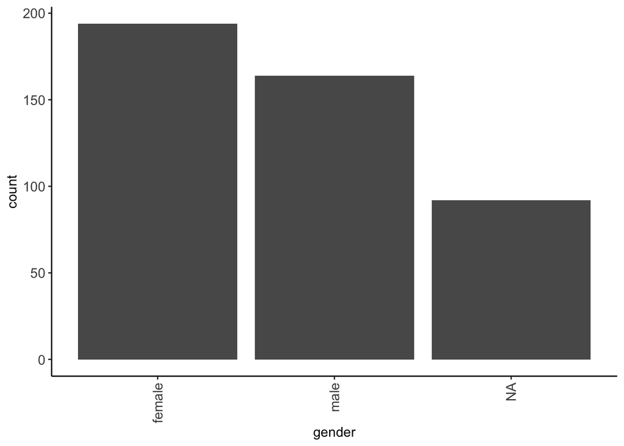

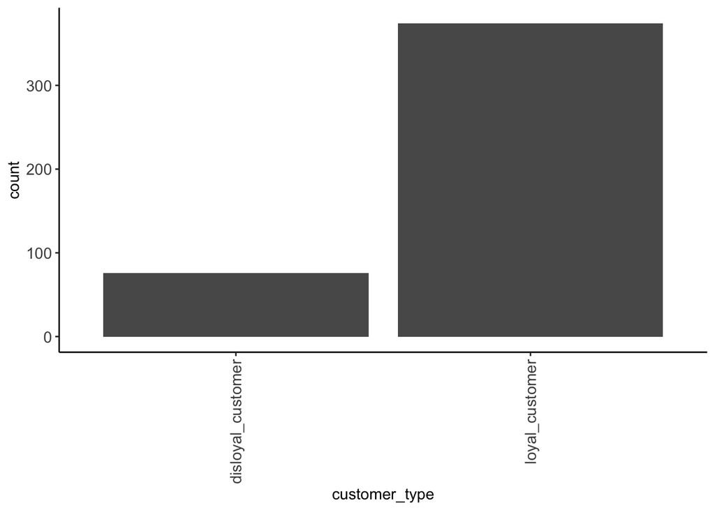

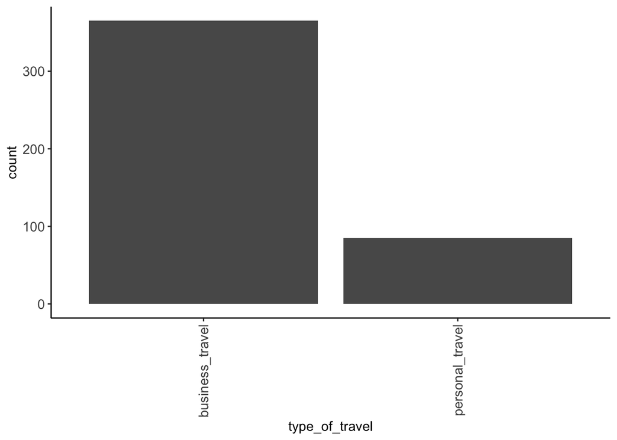

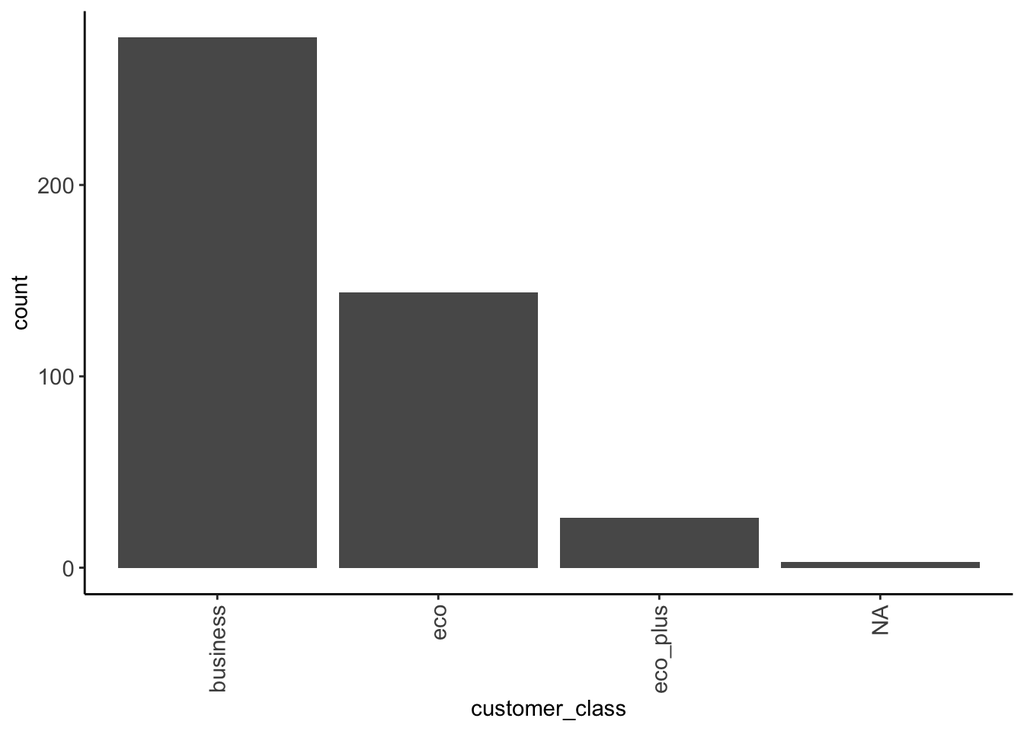

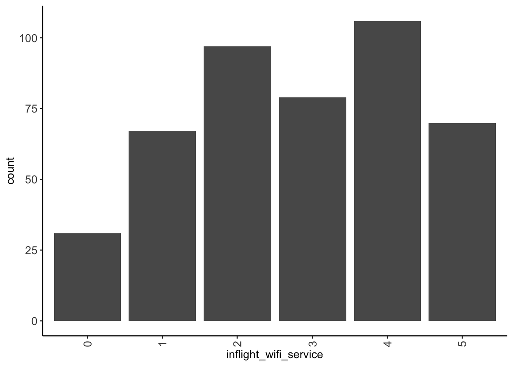

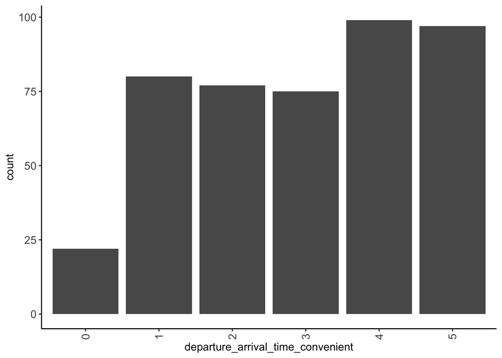

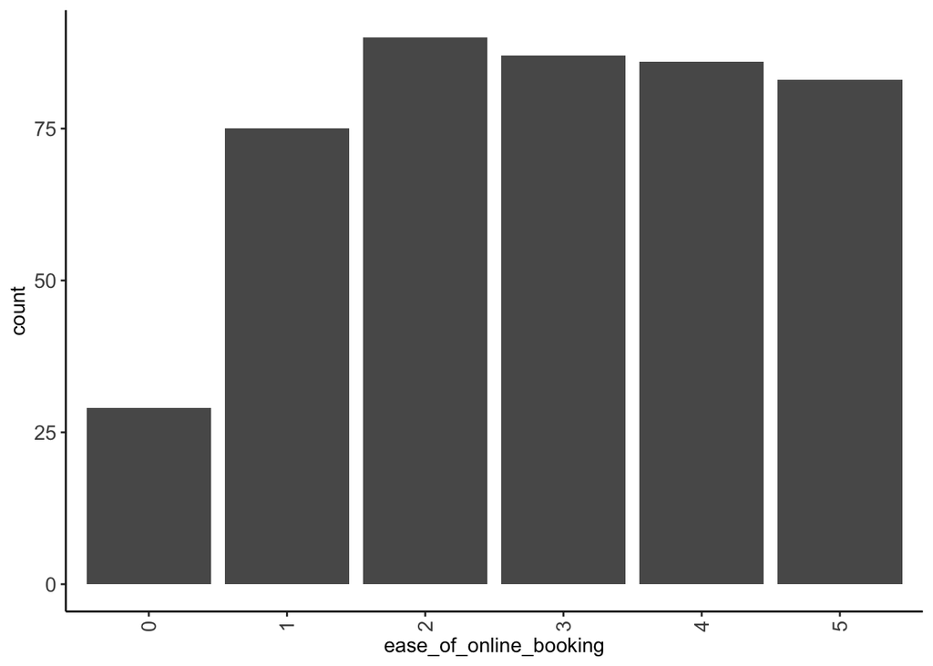

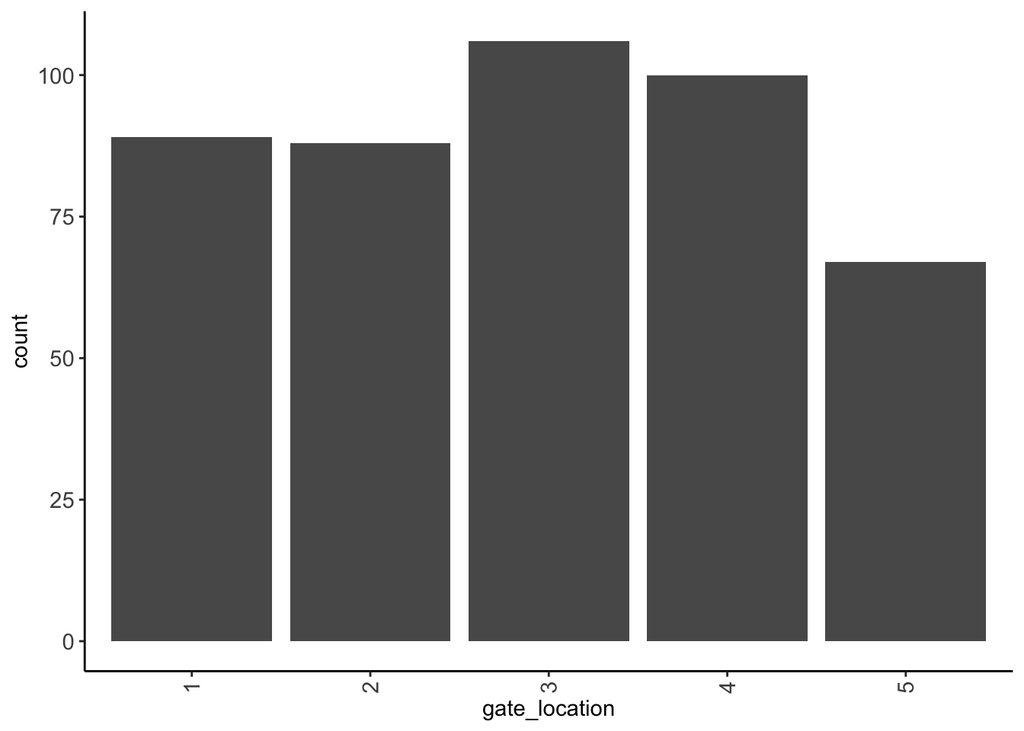

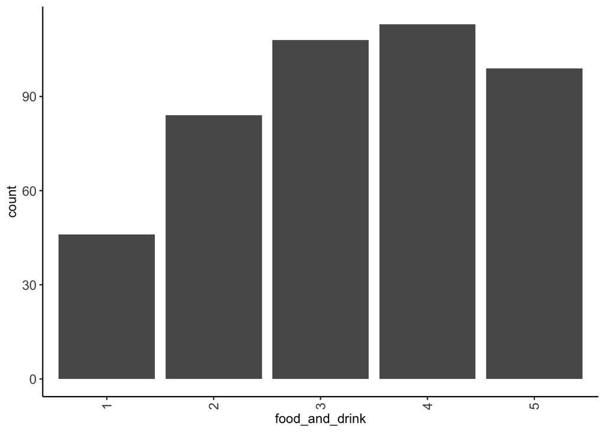

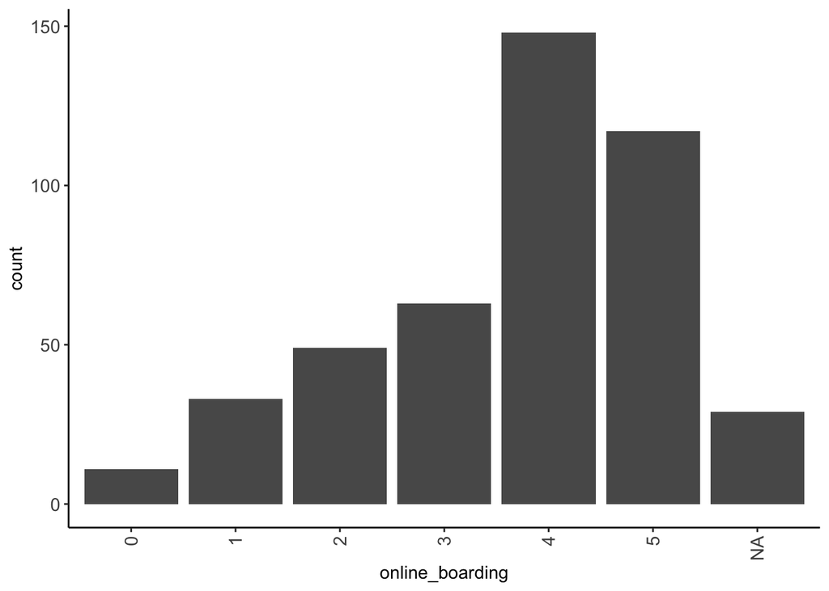

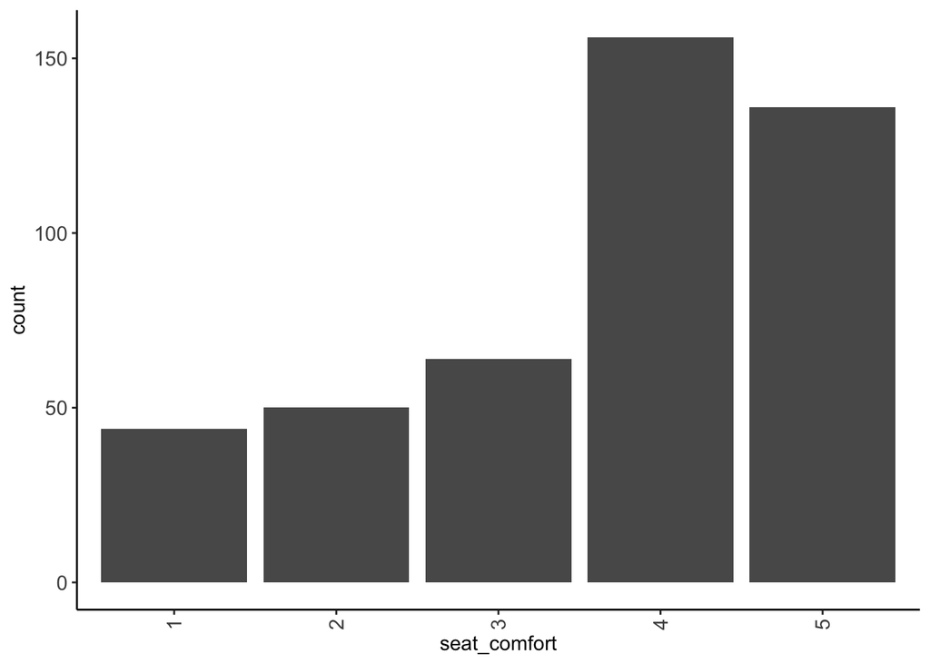

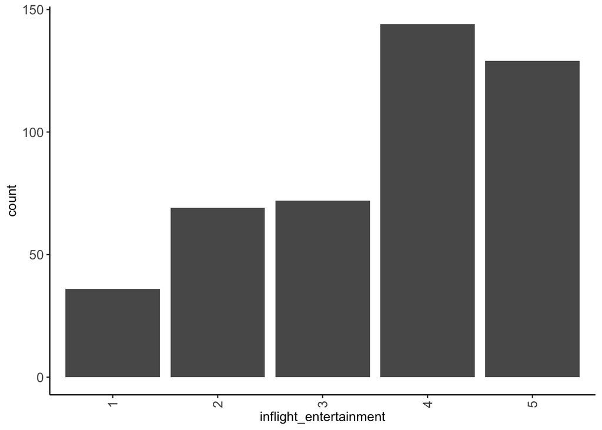

[6 more figures not shown]

```r
data_trn |>
  select(where(is.factor)) |>
  names() |>
  setdiff("satisfaction") |>
  map(\(name) plot_bar(df = data_trn, x = name))
```

### Numeric Predictors

I decided to plot combined box and violin plots to visualize univariate distributions of our numeric predictors. We are able to visualize the median and quartiles, as well as the range of the distribution and outliers (features not available in a violin plot), and we can visualize the shape of the distribution (a feature not available in a boxplot).

Some of the more notable observations in these univariate distributions belong to the following variables:

- `age`: we can see that there is one outlier variable over the age of 80, which we might consider removing.
- `departure_delay_in_minutes`: as indicated before, we can see that our variable is positively skewed, suggesting the need for a transformation during recipe building.
- `arrival_delay_in_minutes`: as indicated before, we can see that our variable is positively skewed, suggesting the need for a transformation during recipe building.

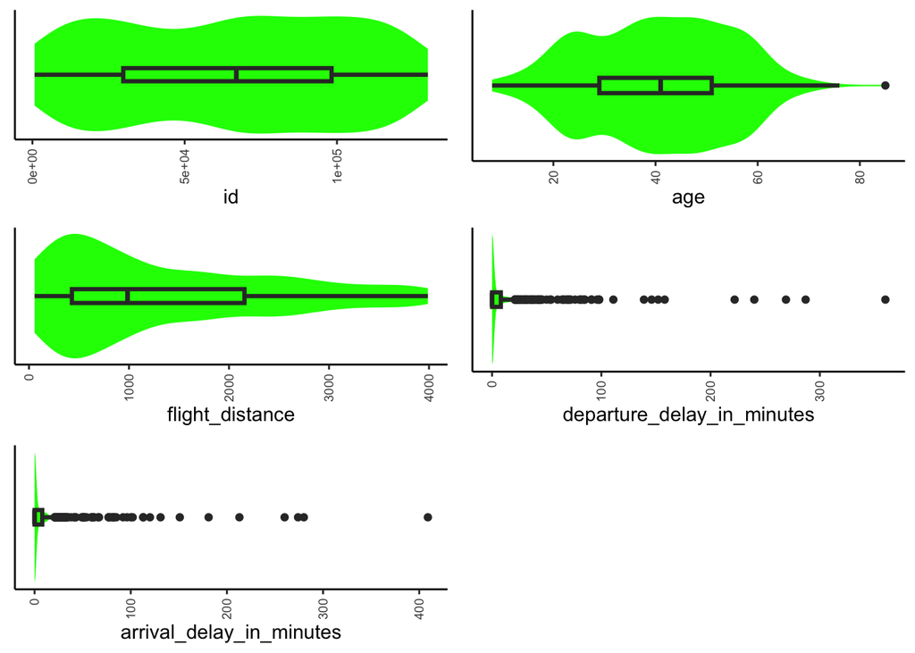

```r
data_trn |>
  select(where(is.numeric)) |>
  names() |>
  map(\(name) plot_box_violin(df = data_trn, x = name)) |>
  plot_grid(plotlist = _, ncol = 2)
```

## Bivariate Distribution

Bivariate relationships with the outcome are useful to detect which predictors display some relationship with the outcome, what feature engineering (transformations) might maximize that relationship, as well as any bivariate (model) outliers.

### Correlation Plot Between Predictors

We’ll start off with a correlation plot of our predictors to assess multicollinearity since some machine learning algorithms are sensitive to high correlations among features.

The correlation plot below is a little crowded, but we can see that `departure_delay_in_minutes` and `arrival_delay_in_minutes` are highly correlated with each other (0.97), and `ease_of_online_booking` and `inflight_wifi_service` are also quite correlated with each other (0.77). This means that we can exclude one variable in each pair during our model building phase to avoid multicollinearity.

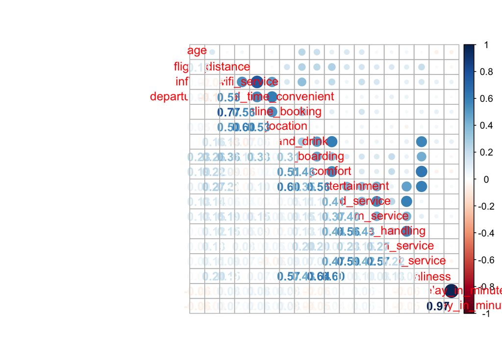

```r
data_trn |>
  mutate(
         inflight_wifi_service = as.numeric(inflight_wifi_service),
         departure_arrival_time_convenient = as.numeric(departure_arrival_time_convenient),
         ease_of_online_booking = as.numeric(ease_of_online_booking),
         gate_location = as.numeric(gate_location),
         food_and_drink  = as.numeric(food_and_drink),
         online_boarding = as.numeric(online_boarding),
         seat_comfort = as.numeric(seat_comfort),
         inflight_entertainment  = as.numeric(inflight_entertainment),
         onboard_service = as.numeric(onboard_service),
         leg_room_service = as.numeric(leg_room_service),
         baggage_handling = as.numeric(baggage_handling),
         checkin_service = as.numeric(checkin_service),
         inflight_service = as.numeric(inflight_service),
         cleanliness = as.numeric(cleanliness)
         ) |>
  select(where(is.numeric), -id) |>
  cor(use = "pairwise.complete.obs") |>
  corrplot::corrplot.mixed()
```

# Model Building & Feature Engineering

To yield the best model predictions, I will be fitting both K-Nearest Neighbors (KNN) and Random Forest models.

## K-Nearest Neighbors (KNN)

I chose to fit a KNN model because it is a non-parametric regression and classification statistical algorithm that is quite flexible and can accommodate many varied Data Generating Processes (DGPs) without the need for much feature engineering with its predictors. Prediction for any new observation in this type of model is based on *k* most similar observations from the dataset.

### KNN Recipe

In the recipe below (`rec_knn`), we are using all the features in our dataset as predictors for our outcome variable, `satisfaction`.

I use the `step_rm` function to remove the following variables from the model: `id`, `gender`, `ease_of_online_booking`, `departure_delay_in_minutes`. I previously mentioned that `gender` would be excluded from the model because of its high missingness. I also previously mentioned that `departure_delay_in_minutes` and `arrival_delay_in_minutes` are highly correlated and `ease_of_online_booking` and `inflight_wifi_service` are also quite correlated, which is why I’m removing one out of each pair.

I used the `step_impute_knn` function to impute missing values for the variables we previously identified as having missingness. I set the number of neighbors to “5”, which means that the function will impute missing data using the nearest 5 neighbors.

I used the `step_filter` function to remove our outlying observation in `age` (i.e. the one individual who was over the age of 80).

The `step_YeoJohnson` function applies the Yeo-Johnson transformation to the `arrival_delay_in_minutes` variable, which is highly positively skewed as mentioned before. This transformation makes skewed data more normally distributed, reducing skewness and stabilizing variance.

I also used the `step_dummy` function to convert all data classed as factors into one or more numeric binary model terms corresponding to the levels of the original data. Since most machine learning models cannot directly process categorical variables, this function replaces all categorical unordered predictors with corresponding dummy variables, allowing for better model compatibility.

The `step_normalize` function transforms each numeric variable so that each feature has a mean of 0 and a standard deviation of 1, ensuring that all variables are scaled appropriately so that none dominate our predictions.

```r
rec_knn <- recipe(satisfaction ~ ., data_trn) |>
  step_rm(id, gender, ease_of_online_booking, departure_delay_in_minutes) |>
  step_impute_knn(customer_class, online_boarding, onboard_service, arrival_delay_in_minutes, neighbors = 5) |>
  step_filter(age <= 80) |>
  step_YeoJohnson(arrival_delay_in_minutes) |>
  step_dummy(all_nominal_predictors()) |>
  step_normalize(all_numeric_predictors())

rec_prep_knn <- rec_knn |>
  prep(data_trn)

feat_trn_knn <- rec_prep_knn |>
  bake(NULL)
```

### Bootstrap Resampling:

Splitting `data_trn` into 100 bootstrap samples stratified on `satisfaction` using a seed for reproducibility. This creates 100 different resampled versions of our training data, while maintaining the same balance/proportions of satisfied and dissatisfied customers in the dataset. This procedure helps us test how stable our model is across different samples of the data. We will use this in both our KNN and Random Forest models.

```r
set.seed(12345)

splits_boot <- data_trn |>
  bootstraps(times = 100, strata = "satisfaction")
```

### KNN Hyperparameter Grid

Setting up a hyperparameter grid to consider a range of values for `neighbors` in our KNN model which, when making a prediction, looks at the K closest data points to a new case and goes with the majority. We begin with a k value of 1 and then go up to 150 in increments of 3 to see which k-value is best.

```r
hyper_grid <- expand.grid(neighbors = seq(1, 150, by = 3))
hyper_grid
```

```
   neighbors
1          1
2          4
3          7
4         10
5         13
6         16
7         19
8         22
9         25
10        28
11        31
12        34
13        37
14        40
```

[output cut: 36 more lines]

### KNN Model Fit & Tuning

We fit a KNN model using the recipe we created above and our bootstrap splits.

- We set our `nearest_neighbor` to be tuned, which means that our model will try varying levels of k with the values and increments specified above.
- We set our engine to `kknn`, which is a specification that runs the KNN package behind the scenes.
- We set our ‘mode’ as `classification`, which means that the output we yield will be either “satisfied” or “neutral_or_dissatisfied” as a response prediction for our outcome variable, `satisfaction`.
- We set our `preprocessor` as `rec_knn`, which is the KNN recipe we created earlier.
- We set our `resamples` to `splits_boot`, which tests our model using the 100 bootstrap samples of our data to see how well it performs on different versions of the dataset.
- We set our `grid` as `hyper_grid`, which is the list of different neighbor values we will be trying (from 1 to 150, in increments of 3).

#### Performance Metric - auROC

Finally, the performance metric we set was `roc_auc`, which tells us how well the model separates the two satisfaction categories.

- I chose to use Receiver Operating Characteristic - Area Under the Curve (auROC) as our performance metric because, if you remember, our outcome variable is unbalanced; there are more “satisfied” observations than “neutral_or_dissatisfied” observations in our outcome (`satisfaction`) variable.
- auROC works well even when classes are unbalanced.
- It tells us how well our model can distinguish between two classes (“satisfied” and “neutral_or_dissatisfied”), across all decision thresholds.
- A higher auROC means better discrimination, making it one of the most reliable and informative metrics for evaluating binary classification models.
  - If the auROC was consistently less than 0.5, then the predictions could be inverted.
  - Values between .70 and .80 are considered fair.
  - Values between .80 and .90 are considered good.
  - Values above .90 are considered excellent.

```r
fits_knn <-
  nearest_neighbor(neighbors = tune()) |>
      set_engine("kknn") |>
      set_mode("classification") |>
      tune_grid(preprocessor = rec_knn,
                resamples = splits_boot,
                grid = hyper_grid,
                metrics = metric_set(roc_auc))
```

### KNN Values

Below, we generate a plot to determine whether we considered a wide enough range of k-values for `neighbors`.

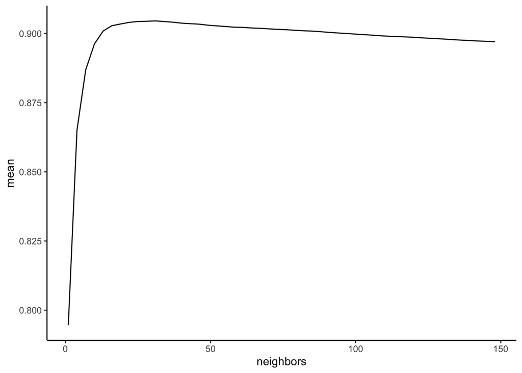

```r
collect_metrics(fits_knn, summarize = TRUE) |>
  ggplot(aes(x = neighbors, y = mean)) +
    geom_line()
```

We know we have considered a wide enough range, because the auROC increases sharply as the number of neighbors increases from 0 - 20, and then slightly but steadily decreases, indicating that our k-value has gotten too large.

Below, we print the best value for the `neighbors` hyperparameter across resamples based on model auROC.

```r
show_best(fits_knn, n = 10)
```

```
# A tibble: 10 × 7
   neighbors .metric .estimator  mean     n std_err .config
       <dbl> <chr>   <chr>      <dbl> <int>   <dbl> <chr>
 1        31 roc_auc binary     0.905   100 0.00205 Preprocessor1_Model11
 2        28 roc_auc binary     0.904   100 0.00210 Preprocessor1_Model10
 3        25 roc_auc binary     0.904   100 0.00210 Preprocessor1_Model09
 4        34 roc_auc binary     0.904   100 0.00204 Preprocessor1_Model12
 5        37 roc_auc binary     0.904   100 0.00203 Preprocessor1_Model13
 6        22 roc_auc binary     0.904   100 0.00213 Preprocessor1_Model08
 7        40 roc_auc binary     0.904   100 0.00200 Preprocessor1_Model14
 8        43 roc_auc binary     0.904   100 0.00202 Preprocessor1_Model15
 9        19 roc_auc binary     0.903   100 0.00212 Preprocessor1_Model07
10        46 roc_auc binary     0.903   100 0.00201 Preprocessor1_Model16
```

From the table, we see that the most ideal number of neighbors (k-value) is 31, yielding a mean auROC score of **0.905** across 100 bootstrap samples.

Finally, we print the average auROC across all k-values that were tested during tuning, telling us how well our KNN model performed on average, regardless of k.

```r
fits_knn |>
  collect_metrics() |>
  filter(.metric == "roc_auc") |>
  summarize(avg_roc_auc = mean(mean))
```

```
# A tibble: 1 × 1
  avg_roc_auc
        <dbl>
1       0.898
```

Thus, regardless of the k-value, the average auROC for our KNN model was **0.898**.

## Random Forest

I chose to fit a Random Forest model as well because tree-based statistical algorithms are flexible and nonparametric.

**Decision trees** partition the feature space into a number of smaller non-overlapping regions with similar responses by using a set of splitting rules. They make response predictions by assigning a single prediction to each of these regions.

**Bagged trees** create multiple bootstrap samples of the training data, then fit a decision tree (base learner) to each sample. Finally, predictions are made by aggregating the predictions across all of the individual base learners. In this case, for classification, it can be either the average of estimated class probabilities or majority class vote across individual base learners.

**Random forests (RFs)** are a modification of bagged decision trees that add an extra layer of randomness. While bagged trees consider all features at each split, Random Forest uses only a random subset (`mtry`) of predictors at each split, which reduces correlation between trees and improves overall prediction.

Fitting a random forest model over a decision tree or bagged trees reduces the risk of overfitting to the training data. RFs natively handle feature interactions and non-linearity and features require little feature engineering. However, RFs can be computationally expensive and less interpretable. Nonetheless, the benefits outweigh the costs.

### RF Hyperparameters

The hyperparameters we will have to tune on are as follows:

- `mtry`: The number of features to randomly select for splitting on each split. A good starting value for classification models (default in the `ranger` package) is $\sqrt{p}$.
- `trees`: The number of bootstrap resamples of the training data to fit decision tree base learners. A good rule of thumb is to start with 10 times the number of features (n = 23). More trees means more computational cost; default in `ranger` is 500.
- `min_n`: Minimum number of observations in a new node rather than min to split. Default in `ranger` is 1 for classification models.

### RF Recipe

In the recipe below (`rec_rf`), we are using all the features in our dataset as predictors for our outcome variable, `satisfaction`.

I use the `step_rm` function to remove the variables, `id`, `gender`, `ease_of_online_booking`and `departure_delay_in_minutes` for all the reasons previously mentioned in the KNN model building section of this report.

I used the `step_impute_knn` function for all the reasons previously mentioned in the KNN model building section of this report.

I used the `step_filter` function to remove our outlying observation in `age` (i.e. the one individual who was over the age of 80).

Variable transformations, dummy coding all categorical predictors, and standardizing all numeric predictors are not required because RF handles them natively; this type of model, if you recall, requires little preprocessing of the data.

```r
rec_rf <- recipe(satisfaction ~ ., data_trn) |>
  step_rm(id, gender, ease_of_online_booking, departure_delay_in_minutes) |>
  step_impute_knn(customer_class, online_boarding, onboard_service, arrival_delay_in_minutes, neighbors = 5) |>
  step_filter(age <= 80)

rec_prep_rf <- rec_rf |>
  prep(data_trn)

feat_trn_rf <- rec_prep_rf |>
  bake(NULL)
```

### RF Tuning Grid

We created a grid of hyperparameter combinations to test when tuning our RF model below.

```r
grid_rf <- expand_grid(mtry = c(5, 10, 20, 25),
                       min_n = c(1, 3, 5, 7, 9, 11, 13, 15, 17, 19))
```

## Model Fit & Tuning

```r
fits_rf <-
    rand_forest(trees = 250,
              mtry = tune(),
              min_n = tune()) |>
    set_engine("ranger",
               respect.unordered.factors = "order",
               oob.error = FALSE,
               seed = 102030) |>
    set_mode("classification") |>
    tune_grid(preprocessor = rec_rf,
              resamples = splits_boot,
              grid = grid_rf,
              metrics = metric_set(roc_auc))
```

### RF Values

Below, we generate a plot to determine whether we selected good combinations of hyperparameters to tune and that the best hyperparameters are inside the range of values considered.

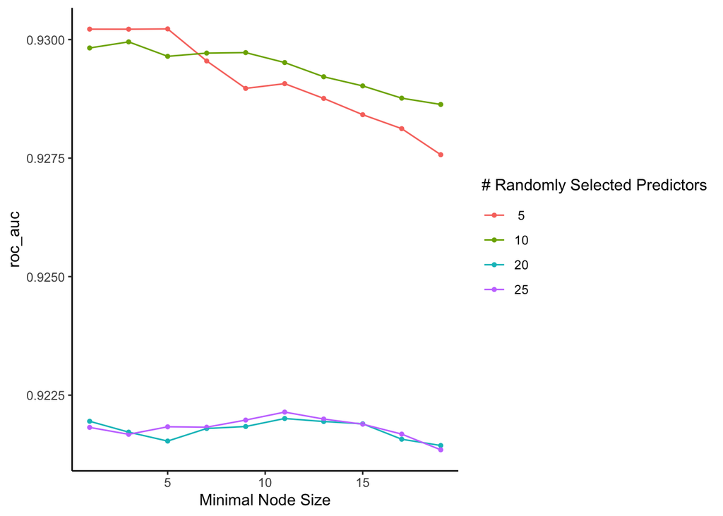

```r
autoplot(fits_rf)
```

This plot shows us that auROC peaks at lower `min_n` values, especially when `mtry` = 5 or 10. Model performance drops slightly as `min_n` increases.

Finally, the following table indicates the highest auROC values according to varying model configurations from our tuning grid.

```r
show_best(fits_rf)
```

```
# A tibble: 5 × 8
   mtry min_n .metric .estimator  mean     n std_err .config
  <dbl> <dbl> <chr>   <chr>      <dbl> <int>   <dbl> <chr>
1     5     5 roc_auc binary     0.930   100 0.00176 Preprocessor1_Model03
2     5     1 roc_auc binary     0.930   100 0.00173 Preprocessor1_Model01
3     5     3 roc_auc binary     0.930   100 0.00173 Preprocessor1_Model02
4    10     3 roc_auc binary     0.930   100 0.00179 Preprocessor1_Model12
5    10     1 roc_auc binary     0.930   100 0.00179 Preprocessor1_Model11
```

Finally, we print the average auROC across all hyperparameter combinations tested during the random forest model tuning process, telling us how well our RF model performed overall, not just for the best combination of hyperparameters.

```r
fits_rf |>
  collect_metrics() |>
  filter(.metric == "roc_auc") |>
  summarize(avg_roc_auc = mean(mean))
```

```
# A tibble: 1 × 1
  avg_roc_auc
        <dbl>
1       0.926
```

Thus, regardless of hyperparameter configuration, the average auROC for our RF model was **0.926**.

# Evaluating Best Model in Test Set

```r
# Reading in the test set data
data_test <- read_csv(here::here(path_data, "data_test.csv"),
                     show_col_types = FALSE) |>
  janitor::clean_names(case = "snake") |>
  mutate(across(where(is.character), factor)) |>
  mutate(across(where(is.factor), tidy_responses)) |>
  class_customer_responses() |>
  glimpse()
```

```
Rows: 150
Columns: 24
$ id                                <dbl> 94031, 1431, 64748, 123100, 22237, 6…
$ gender                            <fct> male, female, male, female, male, ma…
$ customer_type                     <fct> loyal_customer, loyal_customer, loya…
$ age                               <dbl> 32, 43, 44, 43, 40, 60, 46, 36, 25, …
$ type_of_travel                    <fct> business_travel, business_travel, bu…
$ customer_class                    <fct> business, business, business, busine…
$ flight_distance                   <dbl> 1389, 2899, 946, 583, 539, 293, 2446…
$ inflight_wifi_service             <ord> 2, 0, 1, 5, 4, 1, 5, 4, 3, 3, 3, 1, …
$ departure_arrival_time_convenient <ord> 2, 0, 1, 5, 3, 1, 5, 4, 1, 3, 3, 1, …
$ ease_of_online_booking            <ord> 2, 0, 1, 5, 3, 1, 5, 2, 3, 3, 3, 1, …
$ gate_location                     <ord> 2, 5, 1, 5, 3, 1, 5, 4, 3, 3, 3, 1, …
$ food_and_drink                    <ord> 5, 4, 2, 3, 4, 4, 2, 3, 3, 1, 2, 4, …
$ online_boarding                   <ord> 5, 5, 5, 4, 4, 5, 3, 5, 3, 5, 4, 4, …
$ seat_comfort                      <ord> 5, 5, 4, 5, 4, 5, 4, 5, 3, 2, 4, 4, …
$ inflight_entertainment            <ord> 5, 2, 5, 4, 4, 5, 4, 4, 3, 5, 4, 4, …
$ onboard_service                   <ord> 4, 2, 5, 4, 5, 5, 4, 4, 5, 5, 4, 4, …
$ leg_room_service                  <ord> 5, 2, 5, 4, 4, 5, 4, 4, 1, 5, 5, 2, …
$ baggage_handling                  <ord> 5, 2, 5, 4, 1, 5, 4, 4, 3, 5, 4, 5, …
$ checkin_service                   <ord> 5, 3, 3, 3, 4, 3, 5, 4, 2, 4, 3, 3, …
$ inflight_service                  <ord> 5, 2, 5, 4, 4, 5, 4, 4, 3, 5, 4, 4, …
$ cleanliness                       <ord> 5, 4, 4, 5, 4, 4, 4, 5, 3, 4, 3, 4, …
$ departure_delay_in_minutes        <dbl> 67, 6, 8, 0, 0, 0, 0, 0, 0, 6, 0, 36…
$ arrival_delay_in_minutes          <dbl> 79, 0, 5, 0, 0, 0, 0, 0, 0, 0, 6, 34…
$ satisfaction                      <fct> satisfied, satisfied, satisfied, sat…
```

Based on average auROC metrics, I will be choosing our **Random Forest** model as the best model based on bootstrapped performance in the training data. Below are the steps I am taking to evaluate the performance of our chosen model in our held-out test set.

```r
feat_test <- rec_prep_rf |>
  bake(data_test)

# best model
best_rf <-
  rand_forest(trees = 250,
              mtry = select_best(fits_rf)$mtry,
              min_n = select_best(fits_rf)$min_n) |>
  set_engine("ranger",
             respect.unordered.factors = "order",
             oob.error = FALSE,
             seed = 102030) |>
  set_mode("classification") |>
  fit(satisfaction ~ ., feat_trn_rf)
```

## Performance (auROC) in Test Set

Finally, we will compute the auROC value for our RF model on the test set.

```r
# auROC value
roc_auc_vec(fct_rev(feat_test$satisfaction),
            predict(best_rf,
                    feat_test,
                    type = "prob")$.pred_satisfied)
```

```
[1] 0.9472
```

We yielded an auROC value of **0.9472** in the test set, indicating that our model is 94.72% likely to assign a higher predicted probability to a randomly selected satisfied customer than to a dissatisfied one. This value suggests that our model is very effective at distinguishing satisfied from dissatisfied customers, even under varied decision thresholds. We have shown excellent model discriminatory power, and strong generalization to unseen data.

## Visualizing Model Performance

The plot below shows a confusion-style dot plot comparing the actual vs. predicted airline customer satisfaction for our test data.

- X-axis: Actual satisfaction observations (`neutral_or_dissatisfied` vs. `satisfied`)
- Y-axis: Predicted satisfaction values (`neutral_or_dissatisfied` vs. `satisfied`)
- Dots: Individual predictions
- Color:
  - Red (Correct): The prediction matches the actual satisfaction observations.
  - Blue (Incorrect): The prediction does not match the actual satisfaction observations.

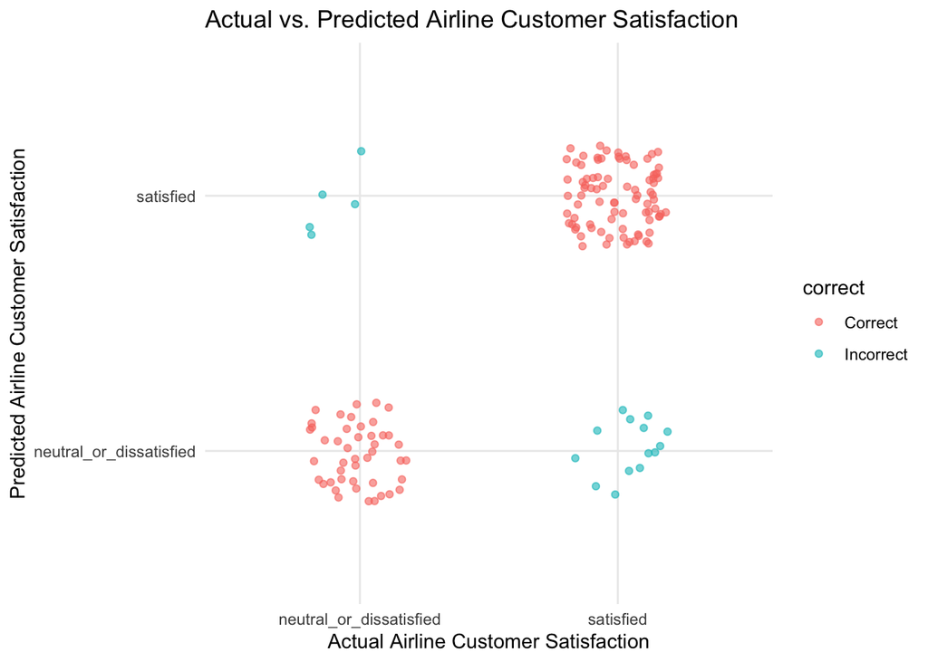

```r
test_preds_class <- predict(best_rf, feat_test, type = "class") |>
  bind_cols(feat_test) |>
  mutate(correct = ifelse(.pred_class == satisfaction, "Correct", "Incorrect"))

ggplot(test_preds_class, aes(x = satisfaction, y = .pred_class, color = correct)) +
  geom_jitter(width = 0.2, height = 0.2, alpha = 0.6) +
  theme_minimal() +
  labs(title = "Actual vs. Predicted Airline Customer Satisfaction",
       x = "Actual Airline Customer Satisfaction",
       y = "Predicted Airline Customer Satisfaction")
```

# Summary

## Spending Our Data

I split the full dataset into a training set (75%) and a test set (25%), using stratified sampling on the outcome variable, `satisfaction`, to maintain the class imbalance ratio in both sets (see **Train/Test Split** section). I set a random seed to ensure reproducibility of the split.

- The training set was used for model fitting and tuning via bootstrapped resampling.
- The test set was held out entirely for final model evaluation to provide an unbiased estimate of performance on unseen data.

One reason I chose this split was because the more data that a model uses to train on, the more accurate one’s predictions for the test set will be. However, it is important to maintain a balance; there must be enough data in our test set to provide a reliable measure of our best model’s performance. There were only 600 observations in the full dataset, which is why I chose to do a train/test split, rather than a train/validation/test split.

## Model Configurations

I considered two flexible, nonparametric models: **K-Nearest Neighbors (KNN)** and **Random Forests (RF)**. Both were tuned across hyperparameter grids:

## Model Selection

Model performance was evaluated using area under the ROC curve (auROC). This metric was chosen because:

- Our outcome variable (`satisfaction`) was unbalanced, with more “satisfied” responses than “neutral_or_dissatisfied”.
- Accuracy would have favored the majority class and given misleading impressions of performance.
- auROC evaluates the model’s ability to rank predictions correctly across all thresholds and is robust to class imbalance.

## Model Characterization

Across 100 bootstrapped samples:

- The best KNN model achieved an average auROC of 0.905
- The best RF model achieved an average auROC of 0.930

Given this difference, I selected the Random Forest model as the best performing model.

To characterize the best model’s performance on new data, I applied it to the held-out test set and computed the test auROC, which was 0.9472.

All-in-all, our model is very effective at distinguishing satisfied from dissatisfied customers, even under varied decision thresholds. Moreover, we have shown excellent model discriminatory power, and strong generalization to unseen data.

Please let me know if you have any questions about this report, thank you!